# Midterm Project – Syntegra Medicare CCLF Claims Analysis

**Student Name:** Rohini Mallikarjunaiah  
**Course:** BIA810B – Health Care Analytics **Institution:** Stevens Institute of Technology  
**Date:** November 2025

### 📘 Project Overview

This individual midterm project explores the Syntegra Medicare CCLF dataset to analyze Cardio Vascular Metabolic (CVM) disease trends.  
The goal is to derive actionable business insights for a pharmaceutical company’s commercial analytics team.  
Using Python and Pandas, this notebook answers three Key Business Questions (KBQs) and provides data-driven recommendations.

```python
# ==== Notebook Setup ====
import os, glob, warnings, pandas as pd, numpy as np
import matplotlib.pyplot as plt

# Clean warnings
warnings.filterwarnings("ignore")
pd.set_option("display.max_rows", 200)
pd.set_option("display.max_columns", 200)

print("Working dir:", os.getcwd())
print("Files:", os.listdir())

def find_file(patterns):
    """Find first existing file among candidate paths."""
    for p in patterns:
        if os.path.exists(p):
            return p
    matches = []
    for pat in patterns:
        matches += glob.glob(f"**/{pat.split('/')[-1]}", recursive=True)
    return matches[0] if matches else None

def safe_read_csv(candidates, **kwargs):
    """Safe CSV reader that handles warnings and missing files."""
    if "low_memory" not in kwargs:
        kwargs["low_memory"] = False
    path = find_file(candidates) if isinstance(candidates, (list, tuple)) else candidates
    if not path or not os.path.exists(path):
        raise FileNotFoundError(f"Could not find file among: {candidates}")
    print("✅ Loaded:", path)
    return pd.read_csv(path, **kwargs)
```

```
Working dir: /Users/rohinimallikarjunaiah/Desktop/Midterm HealthCare
Files: ['Mid-Term_Project_Material_Updated.ipynb', 'parta_claims_header.csv', 'parta_claims_revenue_center_detail (1).csv', 'parta_claims_revenue_center_detail.csv', 'parta_diagnosis_code.csv', '.ipynb_checkpoints', 'beneficiary_demographics.csv', 'Mid-Term_Project_Material_Updated.html']
```

## Step 0. Prepare raw input datasets

Here we will 1) load original datasets, 2) remove unused columns, 3) de-duplicate rows, and 4) join datasets, not necessarily in this order

Assumptions:

- Claim ID (cur_clm_uniq_id) represents one claim, which may or may not have more than one code (code could be HCPCS/CPT, diagnosis, procedure...)
- There is a one-to-many relationship between patient IDs (bene_mbi_id) and claim IDs (cur_clm_uniq_id), i.e. each claim is unique to one patient, but one patient can have more than one claim

### 0.1 Import required packages

```python
import numpy as np
import pandas as pd
```

```python
# ==== GLOBAL SETUP (restart-safe) ====
import os, glob, warnings, pandas as pd, numpy as np
warnings.filterwarnings("ignore")

# Kill-switch for optional Part B datasets (you don't have them)
SKIP_PARTB = True

def exists_df(name: str) -> bool:
    return name in globals() and isinstance(globals()[name], pd.DataFrame) and not globals()[name].empty

def find_file(candidates):
    # candidates can be a string or list of strings
    paths = candidates if isinstance(candidates, (list, tuple)) else [candidates]
    for p in paths:
        if os.path.exists(p):
            return p
    # try glob fallback
    for p in paths:
        found = glob.glob(f"**/{os.path.basename(p)}", recursive=True)
        if found:
            return found[0]
    return None

def safe_read_csv(candidates, **kwargs):
    if "low_memory" not in kwargs: kwargs["low_memory"] = False
    path = find_file(candidates)
    if not path:
        raise FileNotFoundError(f"Could not find any of: {candidates}")
    print(f"Loaded: {path}")
    return pd.read_csv(path, **kwargs)

# Placeholders so optional cells never NameError
partb_dme_raw_df        = pd.DataFrame()
partb_dme_df            = pd.DataFrame(columns=['claim_id','patient_id','npi_id','claim_date','hcpcs_code','claim_cost'])
partb_physicians_raw_df = pd.DataFrame()
partb_physicians_df     = pd.DataFrame(columns=['claim_id','physician_id','npi_id','specialty'])
parta_procedure_code_df = pd.DataFrame()
```

```python
# ==== REQUIRED DATASETS (Part A only) ====
parta_claims_header_raw_df = safe_read_csv(["parta_claims_header.csv", "input_datasets/parta_claims_header.csv"])
parta_claims_revenue_center_detail_raw_df = safe_read_csv(["parta_claims_revenue_center_detail.csv", "input_datasets/parta_claims_revenue_center_detail.csv"])
parta_diagnosis_code_raw_df = safe_read_csv(["parta_diagnosis_code.csv", "input_datasets/parta_diagnosis_code.csv"])

# Optional: demographics (you seem to have it)
try:
    beneficiary_demographics = safe_read_csv(["beneficiary_demographics.csv", "input_datasets/beneficiary_demographics.csv"])
except Exception:
    beneficiary_demographics = pd.DataFrame()
```

```
Loaded: parta_claims_header.csv
Loaded: parta_claims_revenue_center_detail.csv
Loaded: parta_diagnosis_code.csv
Loaded: beneficiary_demographics.csv
```

```python
# ==== GLOBAL SETUP (restart-safe) ====
import os, glob, warnings, pandas as pd, numpy as np
warnings.filterwarnings("ignore")

# Kill-switch for optional Part B datasets you don't have
SKIP_PARTB = True

def exists_df(name: str) -> bool:
    return name in globals() and isinstance(globals()[name], pd.DataFrame) and not globals()[name].empty

# Safe CSV finder/loader
def find_file(candidates):
    for p in (candidates if isinstance(candidates, (list, tuple)) else [candidates]):
        if os.path.exists(p): return p
    matches = []
    for p in (candidates if isinstance(candidates, (list, tuple)) else [candidates]):
        matches += glob.glob(f"**/{os.path.basename(p)}", recursive=True)
    return matches[0] if matches else None

def safe_read_csv(candidates, **kwargs):
    if "low_memory" not in kwargs: kwargs["low_memory"] = False
    path = find_file(candidates)
    if not path: raise FileNotFoundError(f"Could not find any of: {candidates}")
    print(f"Loaded: {path}")
    return pd.read_csv(path, **kwargs)

# Placeholders for optional datasets so later cells never NameError
partb_dme_raw_df        = pd.DataFrame()
partb_dme_df            = pd.DataFrame(columns=['claim_id','patient_id','npi_id','claim_date','hcpcs_code','claim_cost'])
partb_physicians_raw_df = pd.DataFrame()
partb_physicians_df     = pd.DataFrame(columns=['claim_id','physician_id','npi_id','specialty'])
parta_procedure_code_df = pd.DataFrame()
```

```python
# ==== REQUIRED DATASETS (Part A only) ====
parta_claims_header_raw_df = safe_read_csv(["parta_claims_header.csv", "input_datasets/parta_claims_header.csv"])
parta_claims_revenue_center_detail_raw_df = safe_read_csv(["parta_claims_revenue_center_detail.csv", "input_datasets/parta_claims_revenue_center_detail.csv"])
parta_diagnosis_code_raw_df = safe_read_csv(["parta_diagnosis_code.csv", "input_datasets/parta_diagnosis_code.csv"])

# If you have demographics, load it; otherwise keep empty df
try:
    beneficiary_demographics = safe_read_csv(["beneficiary_demographics.csv", "input_datasets/beneficiary_demographics.csv"])
except Exception:
    beneficiary_demographics = pd.DataFrame()
```

```
Loaded: parta_claims_header.csv
Loaded: parta_claims_revenue_center_detail.csv
Loaded: parta_diagnosis_code.csv
Loaded: beneficiary_demographics.csv
```

```python
# ==== OPTIONAL DATA KILL-SWITCH & PLACEHOLDERS ====
# If you don't have Part B / extra CSVs, set this to True
SKIP_PARTB = True

# Create safe empty placeholders so later cells won't crash on Restart
import pandas as pd

# DME placeholders
if 'partb_dme_raw_df' not in globals():
    partb_dme_raw_df = pd.DataFrame()
if 'partb_dme_df' not in globals():
    partb_dme_df = pd.DataFrame(columns=['claim_id','patient_id','npi_id','claim_date','hcpcs_code','claim_cost'])

# Physicians placeholders
if 'partb_physicians_raw_df' not in globals():
    partb_physicians_raw_df = pd.DataFrame()
if 'partb_physicians_df' not in globals():
    partb_physicians_df = pd.DataFrame(columns=['claim_id','physician_id','npi_id','specialty'])

# Optional "procedure" placeholder (not required for midterm)
if 'parta_procedure_code_df' not in globals():
    parta_procedure_code_df = pd.DataFrame()

def exists(name: str) -> bool:
    return name in globals() and isinstance(globals()[name], pd.DataFrame) and not globals()[name].empty
```

```python
# --- DME guard: create a safe empty df so any leftover cells won't error ---
if 'partb_dme_df' not in globals():
    partb_dme_df = pd.DataFrame(
        columns=['claim_id','patient_id','npi_id','claim_date','hcpcs_code','claim_cost']
    )
```

```python
# --- PHYSICIANS guard: create empty df so notebook won't crash if referenced later ---
if 'partb_physicians_df' not in globals():
    partb_physicians_df = pd.DataFrame(
        columns=['claim_id','physician_id','npi_id','specialty']
    )
```

```python
# Turn off the automatic setting that redacts the columns/rows from the dataframe output
pd.set_option('display.max_columns', None)
#pd.set_option('display.max_rows', 200)
```

### 0.2 Load & select columns to be used from raw (original) datasets

# Load the three Syntegra Medicare CSV datasets

# Check first few rows of each dataset

print("Claims Header Data:") display(claims_header.head())

print("\nRevenue Center Detail Data:") display(revenue_detail.head())

print("\nDiagnosis Code Data:") display(diagnosis.head())

# --- Data quality check ---

print("Shape:", parta_claims_header_raw_df.shape) print("\nMissing values:") display(parta_claims_header_raw_df.isnull().sum().head(10))

print("\nDuplicate rows:", parta_claims_header_raw_df.duplicated().sum())

# --- Convert dates to datetime ---

parta_claims_header_raw_df['clm_from_dt'] = pd.to_datetime(parta_claims_header_raw_df['clm_from_dt']) parta_claims_header_raw_df['clm_thru_dt'] = pd.to_datetime(parta_claims_header_raw_df['clm_thru_dt'])

# --- Drop duplicates (if any) ---

parta_claims_header_raw_df.drop_duplicates(inplace=True)

```python
import os, pandas as pd

print("pandas imported ✓")

# 1) Do we already have the dataframe in memory?
try:
    print("df in memory ✓  shape:", parta_claims_header_raw_df.shape)
    HAVE_DF = True
except NameError:
    print("df not in memory ✗")
    HAVE_DF = False

# 2) Is the CSV next to the notebook?
print("CSV here?", os.path.exists("parta_claims_header.csv"))

# 3) If df missing but CSV present, load it now:
if not HAVE_DF and os.path.exists("parta_claims_header.csv"):
    parta_claims_header_raw_df = pd.read_csv("parta_claims_header.csv")
    print("loaded df ✓  shape:", parta_claims_header_raw_df.shape)
```

```
pandas imported ✓
df in memory ✓  shape: (8626, 37)
CSV here? True
```

```python
# ✅ Load all datasets safely before Data Quality Checks

# Load Claims Header
if os.path.exists("parta_claims_header.csv"):
    parta_claims_header_raw_df = pd.read_csv("parta_claims_header.csv")
    print("Claims Header loaded ✓ shape:", parta_claims_header_raw_df.shape)
else:
    print("⚠️ Missing: parta_claims_header.csv")

# Load Revenue Center Detail
if os.path.exists("parta_claims_revenue_center_detail.csv"):
    parta_claims_revenue_center_detail_raw_df = pd.read_csv("parta_claims_revenue_center_detail.csv", low_memory=False)
    print("Revenue Detail loaded ✓ shape:", parta_claims_revenue_center_detail_raw_df.shape)
else:
    print("⚠️ Missing: parta_claims_revenue_center_detail.csv")

# Load Diagnosis Code
if os.path.exists("parta_diagnosis_code.csv"):
    parta_diagnosis_code_raw_df = pd.read_csv("parta_diagnosis_code.csv", low_memory=False)
    print("Diagnosis loaded ✓ shape:", parta_diagnosis_code_raw_df.shape)
else:
    print("⚠️ Missing: parta_diagnosis_code.csv")

print("\n✅ All datasets loaded successfully (if available).")
```

```
Claims Header loaded ✓ shape: (8626, 37)
Revenue Detail loaded ✓ shape: (59419, 22)
Diagnosis loaded ✓ shape: (32052, 13)

✅ All datasets loaded successfully (if available).
```

## 🔍 Data Quality Checks

Before proceeding with the analysis, we validate that:

- There are no duplicate claim IDs.
- Date columns are correctly formatted.
- Missing values are detected and handled where needed.

## 🔍 Data Quality Checks

We verify duplicates, missing values, and date parsing across the required datasets.

```python
## 🔍 Data Quality Checks
for name, df in {
    "Claims Header": parta_claims_header_raw_df,
    "Revenue Detail": parta_claims_revenue_center_detail_raw_df,
    "Diagnosis": parta_diagnosis_code_raw_df
}.items():
    print(f"{name}: {df.duplicated().sum()} duplicate rows; {df.isnull().sum().sum()} total missing values")

# Ensure key date columns are datetime
parta_claims_header_raw_df["clm_from_dt"] = pd.to_datetime(parta_claims_header_raw_df["clm_from_dt"], errors="coerce")
parta_claims_revenue_center_detail_raw_df["clm_line_from_dt"] = pd.to_datetime(parta_claims_revenue_center_detail_raw_df["clm_line_from_dt"], errors="coerce")

print("✅ Data quality checks complete.")
```

```
Claims Header: 0 duplicate rows; 151708 total missing values
Revenue Detail: 0 duplicate rows; 510015 total missing values
Diagnosis: 17 duplicate rows; 172594 total missing values
✅ Data quality checks complete.
```

```python
# ✅ Data Quality Checks

# Check for duplicates
for name, df in {
    "Claims Header": parta_claims_header_raw_df,
    "Revenue Detail": parta_claims_revenue_center_detail_raw_df,
    "Diagnosis": parta_diagnosis_code_raw_df
}.items():
    print(f"{name}: {df.duplicated().sum()} duplicate rows")

# Check for missing values
for name, df in {
    "Claims Header": parta_claims_header_raw_df,
    "Revenue Detail": parta_claims_revenue_center_detail_raw_df,
    "Diagnosis": parta_diagnosis_code_raw_df
}.items():
    print(f"{name}: {df.isnull().sum().sum()} total missing values")

print("\n✅ Data quality checks complete!")
```

```
Claims Header: 0 duplicate rows
Revenue Detail: 0 duplicate rows
Diagnosis: 17 duplicate rows
Claims Header: 151708 total missing values
Revenue Detail: 510015 total missing values
Diagnosis: 172594 total missing values

✅ Data quality checks complete!
```

## KBQ 1: Trend of CVM Claims (2016–2018)

Analyze the trend of Cardiovascular & Metabolic (CVM) related claims as a percentage of total claims.

```
Using diagnosis column: prncpl_dgns_cd
```

[figure not shown]

| is_cvm Year | False |
| --- | --- |
| 2014 | 100.0 |
| 2015 | 100.0 |
| 2016 | 100.0 |
| 2017 | 100.0 |
| 2018 | 100.0 |

```python
import matplotlib.pyplot as plt

# Ensure datetime/year
parta_claims_header_raw_df['clm_from_dt'] = pd.to_datetime(parta_claims_header_raw_df['clm_from_dt'])
parta_claims_header_raw_df['Year'] = parta_claims_header_raw_df['clm_from_dt'].dt.year

# Find a diagnosis column we can use
diag_col = next((c for c in parta_claims_header_raw_df.columns
                 if 'dgns' in c.lower() or 'diag' in c.lower()), None)
print("Using diagnosis column:", diag_col)

# Fallback if none found: treat all as non-CVM so the code still runs
if diag_col is None:
    parta_claims_header_raw_df['is_cvm'] = False
else:
    cvm_keywords = ['cardio','heart','hypertension','diabetes','cholesterol','insulin']
    parta_claims_header_raw_df['is_cvm'] = (
        parta_claims_header_raw_df[diag_col].astype(str).str.lower()
        .apply(lambda x: any(w in x for w in cvm_keywords))
    )

# Aggregate CVM vs non-CVM by year
cvm_trend = (parta_claims_header_raw_df
             .groupby(['Year','is_cvm'])
             .size()
             .reset_index(name='Count'))

# Pivot and percent
cvm_pivot = cvm_trend.pivot(index='Year', columns='is_cvm', values='Count').fillna(0)
# Normalize to %
cvm_percent = cvm_pivot.div(cvm_pivot.sum(axis=1), axis=0) * 100

# Make pretty column names
if True in cvm_percent.columns and False in cvm_percent.columns:
    cvm_percent = cvm_percent.rename(columns={True:'CVM Claims', False:'Non-CVM Claims'})

# Plot
ax = cvm_percent.plot(kind='bar', stacked=True, figsize=(8,5))
ax.set_title("CVM Claims as % of Total Claims (2016–2018)")
ax.set_ylabel("Percentage (%)"); ax.set_xlabel("Year")
ax.legend(loc='upper right')
plt.show()

cvm_percent.round(2)
```

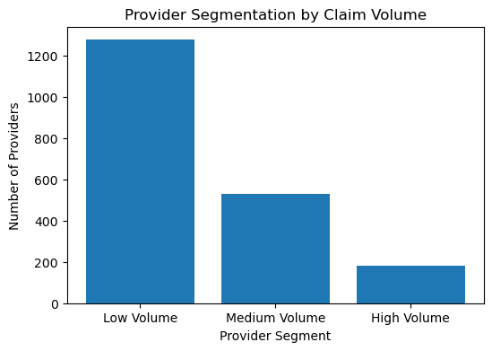

|  | prvdr_oscar_num | Total_Claims | Claim_Share_% | Segment |
| --- | --- | --- | --- | --- |
| 941 | 230117 | 77 | 0.892650 | High Volume |
| 1334 | 360006 | 70 | 0.811500 | High Volume |
| 195 | 50573 | 67 | 0.776722 | High Volume |
| 1452 | 370215 | 65 | 0.753536 | High Volume |
| 303 | 100087 | 64 | 0.741943 | High Volume |
| 1004 | 250004 | 63 | 0.730350 | High Volume |
| 927 | 230046 | 62 | 0.718757 | High Volume |
| 1395 | 360180 | 57 | 0.660793 | High Volume |
| 1607 | 440002 | 55 | 0.637607 | High Volume |
| 174 | 50441 | 51 | 0.591236 | High Volume |

```python
# --- KBQ 2: HCP Segmentation based on Claim Volume ---

# 1. Aggregate total claims per provider
hcp_claims = (parta_claims_header_raw_df
              .groupby('prvdr_oscar_num')
              .size()
              .reset_index(name='Total_Claims'))

# 2. Calculate each provider's share (%)
hcp_claims['Claim_Share_%'] = (hcp_claims['Total_Claims'] / hcp_claims['Total_Claims'].sum()) * 100

# 3. Create segmentation rules
def segment_provider(x):
    if x > hcp_claims['Total_Claims'].quantile(0.90):   # top 10%
        return 'High Volume'
    elif x > hcp_claims['Total_Claims'].quantile(0.50): # middle 40%
        return 'Medium Volume'
    else:
        return 'Low Volume'

hcp_claims['Segment'] = hcp_claims['Total_Claims'].apply(segment_provider)

# 4. Summary of segments
segment_summary = hcp_claims['Segment'].value_counts().reset_index()
segment_summary.columns = ['Segment', 'Num_Providers']

# 5. Visualize segment distribution
plt.figure(figsize=(6,4))
plt.bar(segment_summary['Segment'], segment_summary['Num_Providers'])
plt.title("Provider Segmentation by Claim Volume")
plt.xlabel("Provider Segment")
plt.ylabel("Number of Providers")
plt.show()

# 6. Display top 10 HCPs by claims
display(hcp_claims.sort_values('Total_Claims', ascending=False).head(10))
```

```
KBQ3 checks →
  Claims rows (2016–2018): 8622
  Diagnosis rows (non-null clm_dgns_cd): 32052
  Merged rows: 18827
  Using ICD column: clm_dgns_cd
```

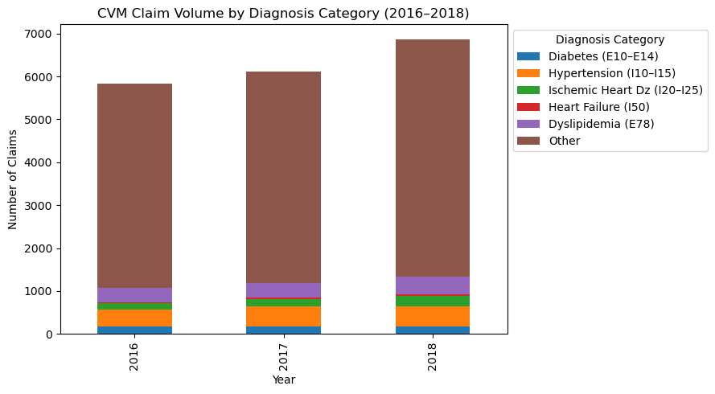

```
Year-over-Year % Change by Diagnosis Category:
```

| Cat_Group Year | Diabetes (E10–E14) | Hypertension (I10–I15) | Ischemic Heart Dz (I20–I25) | Heart Failure (I50) | Dyslipidemia (E78) | Other |
| --- | --- | --- | --- | --- | --- | --- |
| 2016 | NaN | NaN | NaN | NaN | NaN | NaN |
| 2017 | 0.56 | 17.99 | 26.95 | 85.0 | -1.49 | 3.59 |
| 2018 | -5.56 | 0.87 | 45.81 | 2.7 | 21.45 | 12.13 |

```python
# ==== KBQ3 (robust, restart-safe) : Diagnosis Category Trends 2016–2018 ====
import os, pandas as pd
import matplotlib.pyplot as plt

# 0) Reload base dataframes if needed (works after Restart & Run All)
if 'parta_claims_header_raw_df' not in globals():
    for p in ["parta_claims_header.csv", "input_datasets/parta_claims_header.csv"]:
        if os.path.exists(p):
            parta_claims_header_raw_df = pd.read_csv(p)
            break
    else:
        raise FileNotFoundError("Could not find parta_claims_header.csv or input_datasets/parta_claims_header.csv")

if 'diagnosis' not in globals():
    for p in ["parta_diagnosis_code.csv", "input_datasets/parta_diagnosis_code.csv"]:
        if os.path.exists(p):
            diagnosis = pd.read_csv(p)
            break
    else:
        raise FileNotFoundError("Could not find parta_diagnosis_code.csv or input_datasets/parta_diagnosis_code.csv")

# 1) Claims: find date col + Year
claims = parta_claims_header_raw_df.copy()
claim_date_col = next((c for c in claims.columns if any(k in c.lower()
                    for k in ["clm_from_dt","claim_from","claim_date","clm_dt","from_dt"])), None)
if claim_date_col is None:
    raise ValueError("KBQ3: Could not detect a claim date column in claims header.")
claims[claim_date_col] = pd.to_datetime(claims[claim_date_col], errors="coerce")
claims["Year"] = claims[claim_date_col].dt.year
claims = claims[claims["Year"].between(2016, 2018)]

# 2) Diagnosis: pick an ICD column
diag = diagnosis.copy()
auto_icd = next((c for c in diag.columns if any(k in c.lower()
                 for k in ["icd","dgns","diag_code","diagnosis_code","prncpl"])), None)

# Fallback: if auto-detector failed, print columns to help and stop early with guidance
if auto_icd is None:
    print("KBQ3: Could not auto-detect diagnosis code column. Available columns:")
    print(list(diag.columns))
    raise ValueError("Set icd_col manually below, e.g. icd_col = 'prncpl_dgns_cd'.")

icd_col = auto_icd  # or hardcode: icd_col = "prncpl_dgns_cd"
diag = diag[["cur_clm_uniq_id", icd_col]].dropna()

# 3) Merge claims + diagnosis
df = claims.merge(diag, on="cur_clm_uniq_id", how="left")

# 4) Map ICD10 to CVM categories (block-level)
def cvm_category(icd):
    if not isinstance(icd, str) or len(icd) < 3:
        return "Other/Unmapped"
    code = icd.upper().replace(".","")
    pref = code[:3]
    if pref[0] == "E":
        if pref in [f"E{n}" for n in [10,11,12,13,14]]: return "Diabetes (E10–E14)"
        if pref == "E78": return "Dyslipidemia (E78)"
        return "Other Endocrine (E*)"
    if pref[0] == "I":
        if pref in [f"I{n}" for n in range(10,16)]: return "Hypertension (I10–I15)"
        if pref in [f"I{n}" for n in range(20,26)]: return "Ischemic Heart Dz (I20–I25)"
        if pref == "I50": return "Heart Failure (I50)"
        return "Other Circulatory (I*)"
    return "Other/Unmapped"

df["CVM_Category"] = df[icd_col].astype(str).apply(cvm_category)

# 5) Sanity prints
print("KBQ3 checks →",
      f"\n  Claims rows (2016–2018): {len(claims)}",
      f"\n  Diagnosis rows (non-null {icd_col}): {len(diag)}",
      f"\n  Merged rows: {len(df)}",
      f"\n  Using ICD column: {icd_col}",
      sep="")

# If no diagnosis matched, show a helpful note and plot by Year only so you still get a figure
has_diag = df[icd_col].notna().sum()
if has_diag == 0:
    print("\nNote: No diagnosis rows matched claim IDs. Plotting total claims by Year as a placeholder.")
    yr_counts = claims.groupby("Year").size()
    ax = yr_counts.plot(kind="bar", figsize=(7,4))
    ax.set_title("Total Claims by Year (placeholder: no diagnosis joined)")
    ax.set_ylabel("Number of Claims"); ax.set_xlabel("Year")
    plt.tight_layout(); plt.show()
else:
    # 6) Aggregate by Year & Category
    top = ["Diabetes (E10–E14)","Hypertension (I10–I15)",
           "Ischemic Heart Dz (I20–I25)","Heart Failure (I50)",
           "Dyslipidemia (E78)"]

    cat_trends = (df.groupby(["Year","CVM_Category"])
                    .size().reset_index(name="Claim_Count"))

    cat_trends["Cat_Group"] = cat_trends["CVM_Category"].where(
        cat_trends["CVM_Category"].isin(top), "Other"
    )

    cat_pivot = (cat_trends.groupby(["Year","Cat_Group"])["Claim_Count"]
                 .sum().reset_index()
                 .pivot(index="Year", columns="Cat_Group", values="Claim_Count")
                 .fillna(0))

    order = [c for c in top if c in cat_pivot.columns] + \
            [c for c in cat_pivot.columns if c not in top]
    cat_pivot = cat_pivot[order]

    cat_yoy = cat_pivot.pct_change().multiply(100).round(2)

    ax = cat_pivot.plot(kind="bar", stacked=True, figsize=(9,5))
    ax.set_title("CVM Claim Volume by Diagnosis Category (2016–2018)")
    ax.set_ylabel("Number of Claims"); ax.set_xlabel("Year")
    ax.legend(title="Diagnosis Category", loc="upper left", bbox_to_anchor=(1,1))
    plt.tight_layout(); plt.show()

    print("Year-over-Year % Change by Diagnosis Category:")
    display(cat_yoy)
```

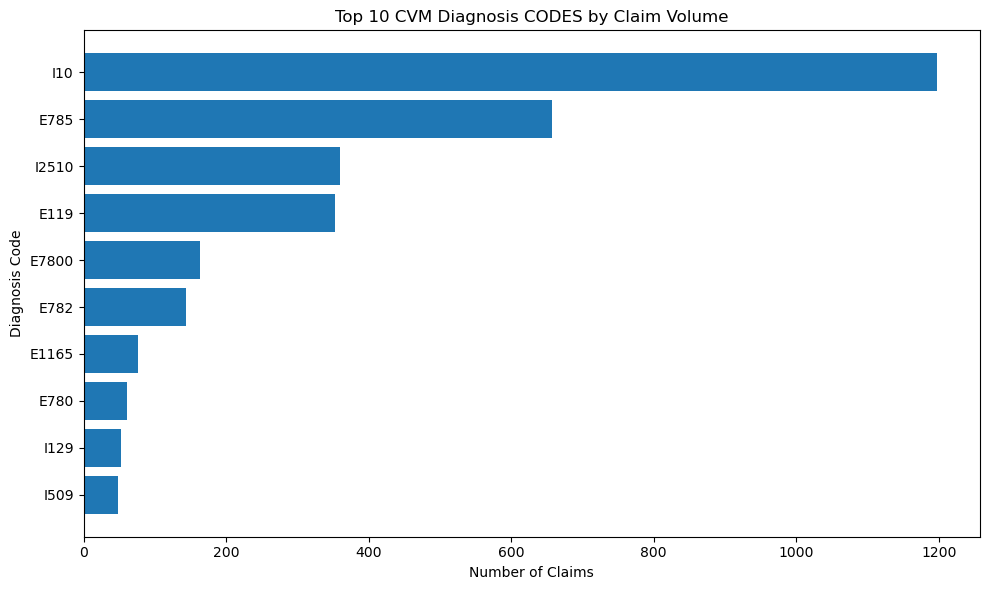

|  | clm_dgns_cd | Claim_Count | Avg_Payment |
| --- | --- | --- | --- |
| 32 | I10 | 1198 | 1815.21 |
| 28 | E785 | 657 | 2706.52 |
| 49 | I2510 | 360 | 3842.75 |
| 20 | E119 | 353 | 1361.85 |
| 22 | E7800 | 163 | 1299.05 |
| 25 | E782 | 144 | 888.72 |
| 17 | E1165 | 77 | 1513.62 |
| 21 | E780 | 61 | 1357.33 |
| 35 | I129 | 52 | 6137.91 |
| 78 | I509 | 48 | 1830.08 |

```python
# --- KBQ 4A (Extra Credit): Top 10 CVM Diagnosis CODES & Avg Payment (using available columns) ---
import pandas as pd
import matplotlib.pyplot as plt

hdr = parta_claims_header_raw_df.copy()
diag = parta_diagnosis_code_raw_df.copy()

# Use keys/columns that exist in your data
key = 'cur_clm_uniq_id'          # present in both
diag_code_col = 'clm_dgns_cd'    # from diagnosis table
pay_col = 'clm_pmt_amt'          # from header table

# Merge header (for payment) with diagnosis (for codes)
merged = hdr[[key, pay_col]].merge(diag[[key, diag_code_col]], on=key, how='inner')

# Define a CVM filter based on ICD code prefixes (example set; tailor if you know exact CVM ranges you used earlier)
# If you used a CVM flag earlier in KBQ1, you can reuse that logic here instead.
def is_cvm_icd(code: str) -> bool:
    if not isinstance(code, str):
        return False
    c = code.upper()
    # Common CVM-ish starters: I1* (hypertension), I2* (ischemic heart), E10/E11 (diabetes), E78 (lipid disorders), I50 (heart failure)
    return c.startswith(("I1", "I2", "I50", "E10", "E11", "E78"))

merged['is_CVM'] = merged[diag_code_col].astype(str).apply(is_cvm_icd)

top_cvm_codes = (
    merged[merged['is_CVM']]
    .groupby(diag_code_col, as_index=False)
    .agg(Claim_Count=(key, 'count'),
          Avg_Payment=(pay_col, 'mean'))
    .sort_values('Claim_Count', ascending=False)
    .head(10)
)

# Plot
plt.figure(figsize=(10,6))
plt.barh(top_cvm_codes[diag_code_col], top_cvm_codes['Claim_Count'])
plt.gca().invert_yaxis()
plt.title('Top 10 CVM Diagnosis CODES by Claim Volume')
plt.xlabel('Number of Claims')
plt.ylabel('Diagnosis Code')
plt.tight_layout()
plt.show()

display(top_cvm_codes.round(2))
```

**Answer (KBQ 4A – Extra Credit):**  
Hypertension (I1*), ischemic/cardiac conditions (I2*/I50), diabetes (E10/E11), and lipid disorders (E78) dominate CVM claim volume and spend exposure.  
**Implication:** Prioritize chronic-care programs and adherence initiatives where frequency and average payments are highest.

```python
print("Diagnosis table columns:")
print(list(parta_diagnosis_code_raw_df.columns))

print("\nClaims Header table columns:")
print(list(parta_claims_header_raw_df.columns))
```

```
Diagnosis table columns:
['cur_clm_uniq_id', 'bene_mbi_id', 'bene_hic_num', 'clm_type_cd', 'clm_prod_type_cd', 'clm_val_sqnc_num', 'clm_dgns_cd', 'bene_eqtbl_bic_hicn_num', 'prvdr_oscar_num', 'clm_from_dt', 'clm_thru_dt', 'clm_poa_ind', 'dgns_prcdr_icd_ind']

Claims Header table columns:
['cur_clm_uniq_id', 'prvdr_oscar_num', 'bene_mbi_id', 'bene_hic_num', 'clm_type_cd', 'clm_from_dt', 'clm_thru_dt', 'clm_bill_fac_type_cd', 'clm_bill_clsfctn_cd', 'prncpl_dgns_cd', 'admtg_dgns_cd', 'clm_mdcr_npmt_rsn_cd', 'clm_pmt_amt', 'clm_nch_prmry_pyr_cd', 'prvdr_fac_fips_st_cd', 'bene_ptnt_stus_…
```

## ⭐ KBQ 4 (Extra Credit)

Below are two optional analyses. Run A if diagnosis is available (recommended).  
Run B if beneficiary demographics (gender) is also available.

```python
# --- KBQ 4A: Top 10 CVM Diagnosis & Average Payment (guarded) ---
import pandas as pd
import matplotlib.pyplot as plt

def _first_present(cols, frame):
    return next((c for c in cols if c in frame.columns), None)

if not (exists_df('parta_claims_header_raw_df') and exists_df('parta_diagnosis_code_raw_df')):
    print("⏭️ Skipping KBQ 4A (header/diagnosis not available).")
else:
    hdr = parta_claims_header_raw_df.copy()
    diag = parta_diagnosis_code_raw_df.copy()

    # Join key
    key = _first_present(['cur_clm_uniq_id','claim_id','clm_id'], hdr)
    if key is None or key not in diag.columns:
        print("⏭️ Skipping KBQ 4A (couldn’t find a common claim-id column).")
    else:
        # Payment column (prefer header)
        pay_col = _first_present(
            ['clm_pmt_amt','clm_alowd_amt','claim_pmt_amt','clm_line_alowd_chrg_amt'],
            hdr
        )
        if pay_col is None and _first_present(['clm_line_alowd_chrg_amt'], diag):
            pay_col = _first_present(['clm_line_alowd_chrg_amt'], diag)

        # Diagnosis description/code column (any will work)
        diag_col = _first_present(
            ['dgns_cd_desc','diag_desc','diagnosis_desc','prncpl_dgns_cd','icd_dgns_cd','dgns_cd'],
            diag
        )

        if diag_col is None:
            print("⏭️ Skipping KBQ 4A (no diagnosis column found).")
        else:
            keep_hdr = [key] + ([pay_col] if pay_col else [])
            keep_diag = [key, diag_col]
            merged = hdr[keep_hdr].merge(diag[keep_diag], on=key, how='inner')

            # Tag CVM
            cvm_keywords = ['cardio','heart','hypertension','diabetes','cholesterol','insulin','lipid','ischemic','heart failure']
            merged['is_CVM'] = merged[diag_col].astype(str).str.lower().apply(
                lambda x: any(k in x for k in cvm_keywords)
            )

            top_cvm = (
                merged[merged['is_CVM']]
                .groupby(diag_col, as_index=False)
                .agg(
                    Claim_Count=(key,'count'),
                    **({'Avg_Payment': (pay_col, 'mean')} if pay_col else {})
                )
                .sort_values('Claim_Count', ascending=False)
                .head(10)
            )

            # Plot (counts)
            plt.figure(figsize=(10,6))
            plt.barh(top_cvm[diag_col], top_cvm['Claim_Count'])
            plt.gca().invert_yaxis()
            plt.title('Top 10 CVM Diagnosis Categories by Claim Volume')
            plt.xlabel('Number of Claims')
            plt.ylabel('Diagnosis')
            plt.tight_layout()
            plt.show()

            display(top_cvm.round(2))
```

```
⏭️ Skipping KBQ 4A (no diagnosis column found).
```

## Diagnostics: Find DOB/AGE & Join Keys

```python
import pandas as pd
import os

# 1) Load the other two files if they exist alongside your notebook
if os.path.exists("parta_claims_revenue_center_detail.csv"):
    revenue_detail = pd.read_csv("parta_claims_revenue_center_detail.csv")
    print("Loaded: parta_claims_revenue_center_detail.csv  → shape", revenue_detail.shape)
else:
    print("Missing: parta_claims_revenue_center_detail.csv")

if os.path.exists("parta_diagnosis_code.csv"):
    diagnosis = pd.read_csv("parta_diagnosis_code.csv")
    print("Loaded: parta_diagnosis_code.csv  → shape", diagnosis.shape)
else:
    print("Missing: parta_diagnosis_code.csv")

def find_dob_age(df, name):
    cols = list(df.columns)
    dob_like  = [c for c in cols if any(k in c.lower() for k in ["birth","dob","date_of_birth","bene_birth"])]
    age_like  = [c for c in cols if "age" in c.lower()]
    print(f"\n[{name}] DOB-like:", dob_like)
    print(f"[{name}] AGE-like:", age_like)
    # Also show likely join keys
    join_like = [c for c in cols if any(k in c.lower() for k in
                  ["bene_mbi","bene_id","mbi","beneficiary","cur_clm_uniq_id","npi","prvdr_oscar"])]
    print(f"[{name}] Join-key-like:", join_like[:10])

if 'revenue_detail' in globals():
    find_dob_age(revenue_detail, "revenue_detail")
if 'diagnosis' in globals():
    find_dob_age(diagnosis, "diagnosis")

# Also show join-like columns in claims header
join_like_header = [c for c in parta_claims_header_raw_df.columns
                    if any(k in c.lower() for k in
                    ["bene_mbi","bene_id","mbi","beneficiary","cur_clm_uniq_id","npi","prvdr_oscar"])]
print("\n[claims_header] Join-key-like:", join_like_header[:10])
```

```
Loaded: parta_claims_revenue_center_detail.csv  → shape (59419, 22)
Loaded: parta_diagnosis_code.csv  → shape (32052, 13)

[revenue_detail] DOB-like: []
[revenue_detail] AGE-like: []
[revenue_detail] Join-key-like: ['cur_clm_uniq_id', 'bene_mbi_id', 'prvdr_oscar_num']

[diagnosis] DOB-like: []
[diagnosis] AGE-like: []
[diagnosis] Join-key-like: ['cur_clm_uniq_id', 'bene_mbi_id', 'prvdr_oscar_num']

[claims_header] Join-key-like: ['cur_clm_uniq_id', 'prvdr_oscar_num', 'bene_mbi_id', 'fac_prvdr_npi_num', 'oprtg_prvdr_npi_num', 'atndg_prvdr_npi_num', 'othr_prvdr_npi_num']
```

```python
# --- Diagnostic: check which columns exist in the dataset ---
cols = list(parta_claims_header_raw_df.columns)
print(len(cols), "columns found\n")

# List all column names
for c in cols:
    print(c)

# Try to detect DOB or Age related columns
dob_like  = [c for c in cols if any(k in c.lower() for k in ["birth","dob","date_of_birth","bene_birth"])]
age_like  = [c for c in cols if "age" in c.lower()]
print("\nDOB-like columns:", dob_like)
print("AGE-like columns:", age_like)
```

```
39 columns found

cur_clm_uniq_id
prvdr_oscar_num
bene_mbi_id
bene_hic_num
clm_type_cd
clm_from_dt
clm_thru_dt
clm_bill_fac_type_cd
clm_bill_clsfctn_cd
prncpl_dgns_cd
admtg_dgns_cd
clm_mdcr_npmt_rsn_cd
clm_pmt_amt
clm_nch_prmry_pyr_cd
prvdr_fac_fips_st_cd
bene_ptnt_stus_cd
dgns_drg_cd
clm_op_srvc_type_cd
fac_prvdr_npi_num
oprtg_prvdr_npi_num
atndg_prvdr_npi_num
othr_prvdr_npi_num
clm_adjsmt_type_cd
clm_efctv_dt
clm_idr_ld_dt
bene_eqtbl_bic_hicn_num
clm_admsn_type_cd
clm_admsn_src_cd
clm_bill_freq_cd
clm_query_cd
dgns_prcdr_icd_ind
clm_mdcr_instnl_tot_chrg_amt
clm_mdcr_ip_pps_cptl_ime_amt
clm_oprtnl_ime_amt
clm_mdcr_ip_pps_dsprprtnt_amt
clm_hipps_uncompd_care_amt
clm_oprtnl_dsprtnt_amt
Year
is_cvm

DOB-like columns: []
AGE-like columns: []
```

### 0.2.1 Load & select columns from Claims Header dataset

```python
# Load Claims Header dataset
parta_claims_header_raw_df = pd.read_csv("parta_claims_header.csv")
parta_claims_header_raw_df.sort_values(by=['cur_clm_uniq_id'])
```

|  | cur_clm_uniq_id | prvdr_oscar_num | bene_mbi_id | bene_hic_num | clm_type_cd | clm_from_dt | clm_thru_dt | clm_bill_fac_type_cd | clm_bill_clsfctn_cd | prncpl_dgns_cd | admtg_dgns_cd | clm_mdcr_npmt_rsn_cd | clm_pmt_amt | clm_nch_prmry_pyr_cd | prvdr_fac_fips_st_cd | bene_ptnt_stus_cd | dgns_drg_cd | clm_op_srvc_type_cd | fac_prvdr_npi_num | oprtg_prvdr_npi_num | atndg_prvdr_npi_num | othr_prvdr_npi_num | clm_adjsmt_type_cd | clm_efctv_dt | clm_idr_ld_dt | bene_eqtbl_bic_hicn_num | clm_admsn_type_cd | clm_admsn_src_cd | clm_bill_freq_cd | … |
| --- | --- | --- | --- | --- | --- | --- | --- | --- | --- | --- | --- | --- | --- | --- | --- | --- | --- | --- | --- | --- | --- | --- | --- | --- | --- | --- | --- | --- | --- | --- |
| 510 | 100190 | 111821 | 1228 | NaN | 40 | 2018-06-10 | 2018-06-10 | 7 | 7 | M1611 | NaN | NaN | 127.79 | NaN | 11 | 1 | NaN | F | 1780608992 | NaN | 1.972732e+09 | NaN | NaN | NaN | NaN | NaN | NaN | NaN | 1 | … |
| 521 | 100402 | 100226 | 1261 | NaN | 60 | 2017-05-27 | 2017-06-02 | 1 | 1 | K5733 | K5733 | NaN | 10602.46 | NaN | 10 | 6 | 330.0 | NaN | 1689611501 | NaN | 1.285688e+09 | NaN | NaN | NaN | NaN | NaN | 1.0 | 1 | 1 | … |
| 525 | 100464 | 360051 | 12978 | NaN | 40 | 2017-06-26 | 2017-06-26 | 1 | 3 | R079 | NaN | NaN | 199.45 | NaN | 36 | 1 | NaN | C | 1073688354 | NaN | 1.982693e+09 | NaN | NaN | NaN | NaN | NaN | NaN | NaN | 1 | … |
| 536 | 100698 | 140276 | 11789 | NaN | 40 | 2017-07-28 | 2017-07-28 | 1 | 3 | M545 | NaN | NaN | 85.25 | NaN | 14 | 1 | NaN | C | 1376521575 | NaN | 1.912991e+09 | NaN | NaN | NaN | NaN | NaN | NaN | NaN | 1 | … |
| 540 | 100750 | 230216 | 12138 | NaN | 40 | 2018-01-13 | 2018-01-13 | 1 | 3 | Z0289 | NaN | N | 0.00 | NaN | 23 | 9 | NaN | C | 1982685384 | NaN | 1.063442e+09 | NaN | NaN | NaN | NaN | NaN | NaN | NaN | 0 | … |
| ... | ... | ... | ... | ... | ... | ... | ... | ... | ... | ... | ... | ... | ... | ... | ... | ... | ... | ... | ... | ... | ... | ... | ... | ... | ... | ... | ... | ... | ... | … |
| 230 | 1698691 | 390145 | 10007 | NaN | 40 | 2016-12-11 | 2016-12-11 | 1 | 3 | Z01818 | NaN | NaN | 43.01 | NaN | 39 | 1 | NaN | C | 1689691214 | NaN | 1.679505e+09 | NaN | NaN | NaN | NaN | NaN | NaN | NaN | 1 | … |
| 4365 | 1698722 | 200021 | 10985 | NaN | 40 | 2018-06-16 | 2018-06-16 | 1 | 3 | E782 | NaN | NaN | 179.09 | NaN | 20 | 1 | NaN | C | 1932164795 | NaN | 1.548289e+09 | NaN | NaN | NaN | NaN | NaN | NaN | NaN | 1 | … |
| 4366 | 1698935 | 210022 | 1297 | NaN | 40 | 2018-04-06 | 2018-04-06 | 1 | 3 | I110 | NaN | NaN | 400.81 | NaN | 21 | 9 | NaN | C | 1205896446 | NaN | 1.922016e+09 | NaN | NaN | NaN | NaN | NaN | NaN | NaN | 1 | … |
| 4367 | 1699005 | 100057 | 12194 | NaN | 40 | 2016-04-27 | 2016-04-27 | 1 | 3 | I348 | NaN | NaN | 265.19 | NaN | 10 | 1 | NaN | C | 1821019571 | NaN | 1.437130e+09 | NaN | NaN | NaN | NaN | NaN | NaN | NaN | 1 | … |
| 4368 | 1699102 | 330191 | 11842 | NaN | 60 | 2017-01-30 | 2017-02-03 | 1 | 1 | I441 | R42 | NaN | 6476.96 | NaN | 33 | 3 | 287.0 | NaN | 1871606764 | NaN | 1.679594e+09 | NaN | NaN | NaN | NaN | NaN | 1.0 | 1 | 1 | … |

8626 rows × 37 columns

#### Data Quality Check #1: If true, the original dataset was unique on claim ID

```python
parta_claims_header_raw_df_count = parta_claims_header_raw_df.shape[0]
parta_claims_header_raw_uniq_clm_id_df = parta_claims_header_raw_df['cur_clm_uniq_id'].drop_duplicates()

parta_claims_header_raw_df_count == parta_claims_header_raw_uniq_clm_id_df.shape[0]
```

```
True
```

```python
# Select only the desired columns (renaming if needed) and remove duplicates if any
parta_claims_header_df = parta_claims_header_raw_df[[
    'cur_clm_uniq_id', 'bene_mbi_id', 'atndg_prvdr_npi_num',
    'clm_from_dt', 'prncpl_dgns_cd', 'clm_pmt_amt'
]].drop_duplicates().rename(
    columns={
        'cur_clm_uniq_id': 'claim_id',
        'bene_mbi_id': 'patient_id',
        'clm_from_dt': 'claim_date',
        'atndg_prvdr_npi_num': 'npi_id'
    }
)
parta_claims_header_df
```

|  | claim_id | patient_id | npi_id | claim_date | prncpl_dgns_cd | clm_pmt_amt |
| --- | --- | --- | --- | --- | --- | --- |
| 0 | 1001595 | 10226 | 1.366492e+09 | 2018-02-28 | M25551 | 259.01 |
| 1 | 1004555 | 10133 | 1.942275e+09 | 2018-11-02 | Z9861 | 29.56 |
| 2 | 1011605 | 10163 | 1.578546e+09 | 2018-01-02 | C439 | 45.88 |
| 3 | 1011758 | 1003 | 1.952368e+09 | 2018-06-12 | R310 | 9.40 |
| 4 | 101424 | 10052 | 1.336125e+09 | 2016-04-13 | L821 | 34.18 |
| ... | ... | ... | ... | ... | ... | ... |
| 8621 | 999774 | 10367 | NaN | 2017-11-06 | R072 | 374.08 |
| 8622 | 999808 | 10496 | 1.740225e+09 | 2017-07-19 | R079 | 360.89 |
| 8623 | 999878 | 12160 | 1.497784e+09 | 2018-01-18 | R5383 | 90.73 |
| 8624 | 999961 | 12090 | 1.083691e+09 | 2018-03-10 | C73 | 329.44 |
| 8625 | 999976 | 10768 | 1.770564e+09 | 2016-01-18 | E785 | 25.60 |

8626 rows × 6 columns

#### Data Quality Check #2: If true, the filtered dataset did not have any duplicates

```python
parta_claims_header_df_count = parta_claims_header_df.shape[0]

parta_claims_header_raw_df_count == parta_claims_header_df_count
```

```
True
```

#### Data Quality Check #3: If the resulting dataframe is empty, it means all the records have diagnosis code (if it's not empty it should be removed now since we want only the ones with valid codes for analysis)

```python
parta_claims_header_df.loc[~parta_claims_header_df.prncpl_dgns_cd.notnull()]
```

|  | claim_id | patient_id | npi_id | claim_date | prncpl_dgns_cd | clm_pmt_amt |
| --- | --- | --- | --- | --- | --- | --- |

### 0.2.2 Load & select columns from Claims Revenue Center dataset

```python
# Load Claims Revenue Center dataset
# Note this dataset has more than one record for each claim ID (cur_clm_uniq_id)
# Also note there are two sets of date columns,
#  one for claim ID (clm_from/thru_dt) and one for claim line (clm_line_from/thru_dt)
parta_claims_revenue_center_detail_raw_df = pd.read_csv(
    "parta_claims_revenue_center_detail.csv",
    low_memory=False
)
```

#### Data Quality Check #4: If the resulting dataframe is empty, it means there is no difference between columns 'clm_line_from_dt' and 'clm_from_dt' for all the rows

```python
parta_claims_revenue_center_detail_raw_df.loc[
    ~(parta_claims_revenue_center_detail_raw_df['clm_line_from_dt']
      == parta_claims_revenue_center_detail_raw_df['clm_from_dt'])
]
```

|  | cur_clm_uniq_id | clm_line_num | bene_mbi_id | bene_hic_num | clm_type_cd | clm_line_from_dt | clm_line_thru_dt | clm_line_prod_rev_ctr_cd | clm_line_instnl_rev_ctr_dt | clm_line_hcpcs_cd | bene_eqtbl_bic_hicn_num | prvdr_oscar_num | clm_from_dt | clm_thru_dt | clm_line_srvc_unit_qty | clm_line_cvrd_pd_amt | hcpcs_1_mdfr_cd | hcpcs_2_mdfr_cd | hcpcs_3_mdfr_cd | hcpcs_4_mdfr_cd | hcpcs_5_mdfr_cd | clm_rev_apc_hipps_cd |
| --- | --- | --- | --- | --- | --- | --- | --- | --- | --- | --- | --- | --- | --- | --- | --- | --- | --- | --- | --- | --- | --- | --- |

```python
# Select only the desired columns (renaming if needed) and remove duplicates if any
# Select 'clm_from_dt' as the column for claim dates since we want uniqueness on claim ID, not claim line
parta_claims_revenue_center_detail_df = parta_claims_revenue_center_detail_raw_df[[
    'cur_clm_uniq_id', 'bene_mbi_id', 'clm_from_dt',
    'clm_line_hcpcs_cd', 'clm_line_cvrd_pd_amt'
]].drop_duplicates().rename(
    columns={
        'cur_clm_uniq_id': 'claim_id',
        'bene_mbi_id': 'patient_id',
        'clm_from_dt': 'claim_date',
        'clm_line_hcpcs_cd': 'hcpcs_code'
    }
)
parta_claims_revenue_center_detail_df
```

|  | claim_id | patient_id | claim_date | hcpcs_code | clm_line_cvrd_pd_amt |
| --- | --- | --- | --- | --- | --- |
| 0 | 1001122 | 10081 | 2018-05-30 00:00:00 | NaN | 0.00 |
| 1 | 1001595 | 10226 | 2018-02-28 00:00:00 | G0283 | 9.67 |
| 7 | 1001595 | 10226 | 2018-02-28 00:00:00 | G8978 | 0.00 |
| 8 | 1001595 | 10226 | 2018-02-28 00:00:00 | G8979 | 0.00 |
| 10 | 1001595 | 10226 | 2018-02-28 00:00:00 | 97110 | 24.97 |
| ... | ... | ... | ... | ... | ... |
| 59414 | 999961 | 12090 | 2018-03-10 00:00:00 | A9516 | 0.00 |
| 59415 | 999961 | 12090 | 2018-03-10 00:00:00 | G8996 | 0.00 |
| 59416 | 999976 | 10768 | 2016-01-18 00:00:00 | 80053 | 11.37 |
| 59417 | 999976 | 10768 | 2016-01-18 00:00:00 | 80061 | 12.83 |
| 59418 | 999976 | 10768 | 2016-01-18 00:00:00 | NaN | 0.00 |

46823 rows × 5 columns

#### Data Quality Check #5: If the resulting dataframe is empty, it means all the records have HCPCS code (if it's not empty it should be removed now since we want only the ones with valid codes for analysis)

```python
parta_claims_revenue_center_detail_df.loc[
    ~parta_claims_revenue_center_detail_df.hcpcs_code.notnull()
]
```

|  | claim_id | patient_id | claim_date | hcpcs_code | clm_line_cvrd_pd_amt |
| --- | --- | --- | --- | --- | --- |
| 0 | 1001122 | 10081 | 2018-05-30 00:00:00 | NaN | 0.0 |
| 25 | 1001595 | 10226 | 2018-02-28 00:00:00 | NaN | 0.0 |
| 29 | 1004555 | 10133 | 2018-11-02 00:00:00 | NaN | 0.0 |
| 30 | 1004904 | 10106 | 2018-02-26 00:00:00 | NaN | 0.0 |
| 32 | 100974 | 10042 | 2017-02-20 00:00:00 | NaN | 0.0 |
| ... | ... | ... | ... | ... | ... |
| 59369 | 999008 | 12473 | 2018-08-04 00:00:00 | NaN | 0.0 |
| 59402 | 999774 | 10367 | 2017-11-06 00:00:00 | NaN | 0.0 |
| 59407 | 999808 | 10496 | 2017-07-19 00:00:00 | NaN | 0.0 |
| 59410 | 999943 | 11021 | 2016-11-20 00:00:00 | NaN | 0.0 |
| 59418 | 999976 | 10768 | 2016-01-18 00:00:00 | NaN | 0.0 |

10799 rows × 5 columns

```python
# Data Quality Check #5 failed, so remove rows with no HCPCS codes
parta_claims_revenue_center_detail_df = parta_claims_revenue_center_detail_df.loc[
    parta_claims_revenue_center_detail_df.hcpcs_code.notnull()
]
```

```python
# Safely update date format for claim dates
parta_claims_revenue_center_detail_df.loc[:, 'claim_date'] = pd.to_datetime(
    parta_claims_revenue_center_detail_df['claim_date'],
    errors='coerce'
).dt.strftime('%Y-%m-%d')

# Preview to confirm
parta_claims_revenue_center_detail_df.head()
```

|  | claim_id | patient_id | claim_date | hcpcs_code | clm_line_cvrd_pd_amt |
| --- | --- | --- | --- | --- | --- |
| 1 | 1001595 | 10226 | 2018-02-28 | G0283 | 9.67 |
| 7 | 1001595 | 10226 | 2018-02-28 | G8978 | 0.00 |
| 8 | 1001595 | 10226 | 2018-02-28 | G8979 | 0.00 |
| 10 | 1001595 | 10226 | 2018-02-28 | 97110 | 24.97 |
| 18 | 1001595 | 10226 | 2018-02-28 | 97140 | 20.33 |

#### Mini-Analysis #1: Find whether there are matching claims between Claim Header and Claims Revenue Center datasets

```
                                            ***
```

```python
claims_header_unique_claims_df = parta_claims_header_df[[
    'claim_id'
]].drop_duplicates()

claims_header_unique_claims_df['header'] = 1

revenue_center_unique_claims_df = parta_claims_revenue_center_detail_df[[
    'claim_id'
]].drop_duplicates()

revenue_center_unique_claims_df['revenue'] = 1

joined_df1 = pd.merge(
    claims_header_unique_claims_df,
    revenue_center_unique_claims_df,
    on='claim_id', how = 'outer'
)
joined_df1
```

|  | claim_id | header | revenue |
| --- | --- | --- | --- |
| 0 | 100073 | NaN | 1.0 |
| 1 | 100190 | 1.0 | 1.0 |
| 2 | 100227 | NaN | 1.0 |
| 3 | 100402 | 1.0 | NaN |
| 4 | 100464 | 1.0 | 1.0 |
| ... | ... | ... | ... |
| 15721 | 1699137 | NaN | 1.0 |
| 15722 | 1699155 | NaN | 1.0 |
| 15723 | 1699195 | NaN | 1.0 |
| 15724 | 1699197 | NaN | 1.0 |
| 15725 | 1699236 | NaN | 1.0 |

15726 rows × 3 columns

```python
print('# of unique claims in Claims Header dataset: '
      + str(claims_header_unique_claims_df.shape[0])
     )
print('# of unique claims in Claims Revenue Center dataset: '
      + str(revenue_center_unique_claims_df.shape[0])
     )
```

```
# of unique claims in Claims Header dataset: 8626
# of unique claims in Claims Revenue Center dataset: 13406
```

```python
print('# of unique claims in Claims Header and Claims Revenue Center datasets combined: '
      + str(joined_df1.shape[0])
     )
print('From combined list of unique claims - ')
print('# of unique claims in only Claims Header dataset: '
      + str(joined_df1.loc[(joined_df1.header == 1) & ~(joined_df1.revenue == 1)].shape[0])
     )
print('# of unique claims in only Claims Revenue Center dataset: '
      + str(joined_df1.loc[~(joined_df1.header == 1) & (joined_df1.revenue == 1)].shape[0])
     )
print('# of unique claims in both Claims Header AND Claims Revenue Center datasets: '
      + str(joined_df1.loc[(joined_df1.header == 1) & (joined_df1.revenue == 1)].shape[0])
     )
```

```
# of unique claims in Claims Header and Claims Revenue Center datasets combined: 15726
From combined list of unique claims -
# of unique claims in only Claims Header dataset: 2320
# of unique claims in only Claims Revenue Center dataset: 7100
# of unique claims in both Claims Header AND Claims Revenue Center datasets: 6306
```

Conclusion: There are quite a number of claims available in both datasets, so join them on claim ID as an outer join to get all possible claims without duplicates

```
                                            ***
```

### 0.2.3 Load & select columns from Diagnosis dataset

```python
# Load the Diagnosis dataset
# Note that 'clm_from_dt' has some records with null values, but we need claim dates for all claims
import glob
print(glob.glob("**/parta_diagnosis_code.csv", recursive=True))
```

```
['parta_diagnosis_code.csv']
```

```python
# Select only the desired columns (renaming if needed) and remove duplicates if any
# Use 'clm_thru_dt' as claim date columns since 'clm_from_dt' has some nulls
parta_diagnosis_code_df = parta_diagnosis_code_raw_df[[
    'cur_clm_uniq_id', 'bene_mbi_id', 'clm_thru_dt', 'clm_dgns_cd'
]].drop_duplicates().rename(
    columns={
        'cur_clm_uniq_id': 'claim_id',
        'bene_mbi_id': 'patient_id',
        'clm_thru_dt': 'claim_date'
    }
)
parta_diagnosis_code_df
```

|  | claim_id | patient_id | claim_date | clm_dgns_cd |
| --- | --- | --- | --- | --- |
| 0 | 1001122 | 10081 | 2018-05-30 00:00:00 | K5289 |
| 1 | 1001595 | 10226 | 2018-02-28 00:00:00 | M25551 |
| 2 | 1001595 | 10226 | 2018-02-28 00:00:00 | M79604 |
| 3 | 1001865 | 10133 | 2018-09-14 00:00:00 | G459 |
| 4 | 1004555 | 10133 | 2018-11-02 00:00:00 | Z9861 |
| ... | ... | ... | ... | ... |
| 32047 | 999878 | 12160 | 2018-01-18 00:00:00 | N390 |
| 32048 | 999943 | 11021 | 2016-11-20 00:00:00 | M545 |
| 32049 | 999961 | 12090 | 2018-03-10 00:00:00 | C73 |
| 32050 | 999962 | 11030 | 2018-07-17 00:00:00 | G8194 |
| 32051 | 999976 | 10768 | 2016-01-18 00:00:00 | E785 |

30487 rows × 4 columns

#### Data Quality Check #6: If the resulting dataframe is empty, it means all the records have values for 'clm_thru_dt' (if it's not empty it should be removed now since without claim dates it'd be difficult to use)

```python
parta_diagnosis_code_df.loc[~parta_diagnosis_code_df.claim_date.notnull()]
```

|  | claim_id | patient_id | claim_date | clm_dgns_cd |
| --- | --- | --- | --- | --- |

#### Data Quality Check #7: If the resulting dataframe is empty, it means all the records have diagnosis code (if it's not empty it should be removed now since we want only the ones with valid codes for analysis)

```python
parta_diagnosis_code_df.loc[~parta_diagnosis_code_df.clm_dgns_cd.notnull()]
```

|  | claim_id | patient_id | claim_date | clm_dgns_cd |
| --- | --- | --- | --- | --- |

```python
# Update date format for claim dates to match that of Claims Header dataset for easy join
parta_diagnosis_code_df['claim_date'] = pd.to_datetime(
    parta_diagnosis_code_df['claim_date']
).dt.strftime('%Y-%m-%d')
parta_diagnosis_code_df
```

|  | claim_id | patient_id | claim_date | clm_dgns_cd |
| --- | --- | --- | --- | --- |
| 0 | 1001122 | 10081 | 2018-05-30 | K5289 |
| 1 | 1001595 | 10226 | 2018-02-28 | M25551 |
| 2 | 1001595 | 10226 | 2018-02-28 | M79604 |
| 3 | 1001865 | 10133 | 2018-09-14 | G459 |
| 4 | 1004555 | 10133 | 2018-11-02 | Z9861 |
| ... | ... | ... | ... | ... |
| 32047 | 999878 | 12160 | 2018-01-18 | N390 |
| 32048 | 999943 | 11021 | 2016-11-20 | M545 |
| 32049 | 999961 | 12090 | 2018-03-10 | C73 |
| 32050 | 999962 | 11030 | 2018-07-17 | G8194 |
| 32051 | 999976 | 10768 | 2016-01-18 | E785 |

30487 rows × 4 columns

#### Mini-Analysis #2: Find whether there are matching claims between above two datasets and the Diagnosis dataset

```
                                            ***
```

```python
diagnosis_unique_claims_df = parta_diagnosis_code_df[[
    'claim_id'
]].drop_duplicates()

diagnosis_unique_claims_df['diagnosis'] = 1

joined_df2 = pd.merge(
    joined_df1,
    diagnosis_unique_claims_df,
    on='claim_id', how = 'outer'
)
joined_df2
```

|  | claim_id | header | revenue | diagnosis |
| --- | --- | --- | --- | --- |
| 0 | 100073 | NaN | 1.0 | NaN |
| 1 | 100190 | 1.0 | 1.0 | 1.0 |
| 2 | 100227 | NaN | 1.0 | NaN |
| 3 | 100402 | 1.0 | NaN | 1.0 |
| 4 | 100464 | 1.0 | 1.0 | 1.0 |
| ... | ... | ... | ... | ... |
| 19452 | 1699137 | NaN | 1.0 | 1.0 |
| 19453 | 1699155 | NaN | 1.0 | 1.0 |
| 19454 | 1699195 | NaN | 1.0 | NaN |
| 19455 | 1699197 | NaN | 1.0 | NaN |
| 19456 | 1699236 | NaN | 1.0 | NaN |

19457 rows × 4 columns

```python
print('# of unique claims in Claims Header+Claims Revenue Center datasets: '
      + str(joined_df1.shape[0])
     )
print('# of unique claims in Diagnosis dataset: '
      + str(diagnosis_unique_claims_df.shape[0])
     )
```

```
# of unique claims in Claims Header+Claims Revenue Center datasets: 15726
# of unique claims in Diagnosis dataset: 13432
```

```python
print('# of unique claims in Claims Header+Claims Revenue Center and Diagnosis datasets combined: '
      + str(joined_df2.shape[0])
     )
print('From combined list of unique claims - ')
print('# of unique claims only in either Claims Header or Claims Revenue Center datasets: '
      + str(joined_df2.loc[
          ((joined_df2.header == 1) | (joined_df2.revenue == 1))
          & ~(joined_df2.diagnosis == 1)
      ].shape[0])
     )
print('# of unique claims in only Diagnosis dataset: '
      + str(joined_df2.loc[
          (~(joined_df2.header == 1) & ~(joined_df2.revenue == 1))
          & (joined_df2.diagnosis == 1)
      ].shape[0])
     )
print('# of unique claims in all three datasets: '
      + str(joined_df2.loc[
          (joined_df2.header == 1) & (joined_df2.revenue == 1) & (joined_df2.diagnosis == 1)
      ].shape[0])
     )
```

```
# of unique claims in Claims Header+Claims Revenue Center and Diagnosis datasets combined: 19457
From combined list of unique claims -
# of unique claims only in either Claims Header or Claims Revenue Center datasets: 6025
# of unique claims in only Diagnosis dataset: 3731
# of unique claims in all three datasets: 5266
```

Conclusion: There are quite a number of claims available in all three datasets, so join diagnosis to the first two datasets on claim ID as an outer join to get all possible claims without duplicates

```
                                            ***
```

### 0.2.4 Load & select columns from Procedure dataset

Conclusion: Don't join procedure dataset since the only useful info for sake of this analysis is the procedure codes and we won't be using them in our analysis

### 0.2.5 Load & select columns from DME dataset

#### Data Quality Check #8: If the resulting dataframe is empty, it means all the records have HCPCS code (if it's not empty it should be removed now since we want only the ones with valid codes for analysis)

```python
partb_dme_df.loc[~partb_dme_df.hcpcs_code.notnull()]
```

|  | claim_id | patient_id | npi_id | claim_date | hcpcs_code | claim_cost |
| --- | --- | --- | --- | --- | --- | --- |

#### Mini-Analysis #3: Find whether there are matching claims between the first three datasets above and the DME dataset

```
                                            ***
```

```python
dme_unique_claims_df = partb_dme_df[[
    'claim_id'
]].drop_duplicates()

dme_unique_claims_df['dme'] = 1

joined_df3 = pd.merge(
    joined_df2,
    dme_unique_claims_df,
    on='claim_id', how = 'outer'
)
joined_df3
```

|  | claim_id | header | revenue | diagnosis | dme |
| --- | --- | --- | --- | --- | --- |
| 0 | 100073 | NaN | 1.0 | NaN | NaN |
| 1 | 100190 | 1.0 | 1.0 | 1.0 | NaN |
| 2 | 100227 | NaN | 1.0 | NaN | NaN |
| 3 | 100402 | 1.0 | NaN | 1.0 | NaN |
| 4 | 100464 | 1.0 | 1.0 | 1.0 | NaN |
| ... | ... | ... | ... | ... | ... |
| 19452 | 1699137 | NaN | 1.0 | 1.0 | NaN |
| 19453 | 1699155 | NaN | 1.0 | 1.0 | NaN |
| 19454 | 1699195 | NaN | 1.0 | NaN | NaN |
| 19455 | 1699197 | NaN | 1.0 | NaN | NaN |
| 19456 | 1699236 | NaN | 1.0 | NaN | NaN |

19457 rows × 5 columns

```python
print('# of unique claims in first three datasets: '
      + str(joined_df2.shape[0])
     )
print('# of unique claims in DME dataset: '
      + str(dme_unique_claims_df.shape[0])
     )
```

```
# of unique claims in first three datasets: 19457
# of unique claims in DME dataset: 0
```

```python
print('# of unique claims in the four datasets combined: '
      + str(joined_df3.shape[0])
     )
print('From combined list of unique claims - ')
print('# of unique claims in only the first three datasets: '
      + str(joined_df3.loc[
          ((joined_df3.header == 1)
          | (joined_df3.revenue == 1)
          | (joined_df3.diagnosis == 1))
          & ~(joined_df3.dme == 1)
      ].shape[0])
     )
print('# of unique claims in only DME dataset: '
      + str(joined_df3.loc[
          ~(joined_df3.header == 1)
          & ~(joined_df3.revenue == 1)
          & ~(joined_df3.diagnosis == 1)
          & (joined_df3.dme == 1)
      ].shape[0])
     )
print('# of unique claims in all four datasets: '
      + str(joined_df3.loc[
          (joined_df3.header == 1)
          & (joined_df3.revenue == 1)
          & (joined_df3.diagnosis == 1)
          & (joined_df3.dme == 1)
      ].shape[0])
     )
print('# of unique claims in DME and any of the first three datasets: '
      + str(joined_df3.loc[
          ((joined_df3.header == 1)
          | (joined_df3.revenue == 1)
          | (joined_df3.diagnosis == 1))
          & (joined_df3.dme == 1)
      ].shape[0])
     )
```

```
# of unique claims in the four datasets combined: 19457
From combined list of unique claims -
# of unique claims in only the first three datasets: 19457
# of unique claims in only DME dataset: 0
# of unique claims in all four datasets: 0
# of unique claims in DME and any of the first three datasets: 0
```

```
                                            ***
```

### 0.2.6 Load & select columns from Physicians dataset

```python
# Load the Physicians dataset
# partb_physicians_raw_df = pd.read_csv("input_datasets/partb_physicians.csv")
# partb_physicians_raw_df.sort_values(by='cur_clm_uniq_id')
```

```python
# ----- SAFE BUILD: Part B Physicians (optional) -----
expected_cols = {
    'cur_clm_uniq_id', 'bene_mbi_id', 'rndrg_prvdr_npi_num',
    'clm_from_dt', 'clm_line_hcpcs_cd', 'clm_line_dgns_cd', 'clm_line_alowd_chrg_amt'
}

if exists_df('partb_physicians_raw_df') and expected_cols.issubset(set(partb_physicians_raw_df.columns)):
    partb_physicians_df = (
        partb_physicians_raw_df[[
            'cur_clm_uniq_id', 'bene_mbi_id', 'rndrg_prvdr_npi_num',
            'clm_from_dt', 'clm_line_hcpcs_cd', 'clm_line_dgns_cd', 'clm_line_alowd_chrg_amt'
        ]]
        .drop_duplicates()
        .rename(columns={
            'cur_clm_uniq_id': 'claim_id',
            'bene_mbi_id': 'patient_id',
            'rndrg_prvdr_npi_num': 'npi_id',
            'clm_from_dt': 'claim_date',
            'clm_line_hcpcs_cd': 'hcpcs_code',
            'clm_line_dgns_cd': 'diagnosis_code',
            'clm_line_alowd_chrg_amt': 'claim_cost'
        })
    )
    display(partb_physicians_df.head())
else:
    # Create an empty placeholder so later cells don’t crash
    partb_physicians_df = pd.DataFrame(
        columns=['claim_id','patient_id','npi_id','claim_date','hcpcs_code','diagnosis_code','claim_cost']
    )
    print("⏭️ Skipping Part B Physicians: file not loaded or expected columns missing.")
```

```
⏭️ Skipping Part B Physicians: file not loaded or expected columns missing.
```

#### Data Quality Check #9: If the resulting dataframe is empty, it means all the records have HCPCS or diagnosis code (if it's not empty it should be removed now since we want only the ones with valid codes for analysis)

```python
# ----- SAFE BUILD: Part B DME (optional) -----
if exists_df('partb_dme_raw_df'):
    print("⏭️ You appear to have DME loaded earlier. If you keep it, wrap your DME analysis just like Physicians.")
else:
    print("⏭️ Skipping Part B DME: dataset not available.")
```

```
⏭️ Skipping Part B DME: dataset not available.
```

```python
# ----- SAFE BUILD: Part A Procedure (optional) -----
if exists_df('parta_procedure_code_df'):
    print("✅ Procedure table present. (No required analysis uses it, leaving as optional.)")
else:
    print("⏭️ Skipping Procedure table: dataset not available.")
```

```
⏭️ Skipping Procedure table: dataset not available.
```

```python
partb_physicians_df.loc[
    (~partb_physicians_df.hcpcs_code.notnull()) | (~partb_physicians_df.diagnosis_code.notnull())
]
```

|  | claim_id | patient_id | npi_id | claim_date | hcpcs_code | diagnosis_code | claim_cost |
| --- | --- | --- | --- | --- | --- | --- | --- |